# Process LTER Unispec Data

Ruby An

December 17, 2018

# 1 How to use this R Markdown Notebook:

This R Markdown document will walk you through the steps to process Unispec-DC data collected from the Toolik Arctic LTER plots. For background and additional info, consult *A People’s Guide to Unispec-DC Measurements and Data Prep* in the LTER files.

**To use this notebook INTERACTIVELY**: set `output: html_notebook` in the header at the top of this document. In this mode, you can:

- Look at the output in the “Viewer” Pane of RStudio (choose **“Preview in Viewer Pane”** option under the “gear” icon).
- Clicking the “Preview” button above will also generate a `process_unispe_files.nb.html` file which you can open in your web browser of choice.

The preview will then update every time you rerun code chunks and save this file. To run all code chunks you can use the keyboard shortcut CTL+ALT+R.

**To generate a STATIC report**: choose **Knit to HTML** or PDF to generate a document that includes both written content as well as the output of any embedded R code chunks within the document.

# 2 Choose Directory

Select the folder containing the unispec files you want to process. Run the following code chunk interactively in RStudio to set folder via pop-up window.

```r
## INTERACTIVE CODE (use when in RStudio)
# library("rChoiceDialogs") # for interactively selecting file directories
# data_path <- rchoose.dir(caption = "Select Unispec files directory")
## STATIC CODE (use when Knitting)
data_path  <- "UnispecData/Unispec6/"
```

**Chosen Directory**: UnispecData/Unispec6/

This directory should contain both the `.spu` files you wish to process and a corresponding `*_unispec_key.csv` file. The key file matches the .spu files to the date, site, block, treatment, plot, & measurement and specifies which white references to use to correct for instrument error.

# 3 Load Unispec Data

Run the following code chunks to load & join keys to data from your chosen directory.

## 3.1 Load Keys

```r
## Find all file keys
### alter search pattern to choose specific key(s)
key_files <- list.files(path = data_path, pattern = "*_key.csv", full.names = T, recursive = T)
## Read in data from filekeys
key_list <- data_frame(keyname = key_files) %>% # create dataframe
  mutate(key_contents = map(keyname, function(x) read_key_file(x)))
# read_key_file() is a function I wrote located in the file "unispec_functions.R"
# map function: super useful to apply function to objects without slow "for" loops
## Unpack into usable dataframe
keys <- unnest(key_list)
```

**Chosen Keys**: UnispecData/Unispec6//2018_unispec_key.csv

## 3.2 Load Data

```r
## Find .spu files
### alter data_path or specify Date(s) or Site(s) to read files
files <- list.files(path = data_path, pattern = ".spu$", full.names = T, recursive=T)
## Read data from files (can take minutes)
data_list <- data_frame(filename = files) %>% # create dataframe
  mutate(file_contents = map(filename, function(x) read_spu_file(x)))
## Unpack into usable dataframe
data <- unnest(data_list)
```

## 3.3 Join Data & Keys

```r
## Join all data matching keys dataframe (drops any non-matching data),
##  by columns (Date, Site, FileNum)
df <- inner_join(data, keys) %>%
  filter(Wavelength >= 400 & Wavelength <= 1000) # Choose relevent wavelengths
```

The following table lists the dates and sites of the files contained in your chosen directory:

| Date | Sites |
| --- | --- |
| 2018-08-11 | LMAT,MAT,MNAT,NANT |

# 4 QAQC

Quality check unispec data using the following code chunks.

## 4.1 Check White References

White references correct for instrument & cable irregularities. Multiplying by the correction factor (ChA/ChB) smooths out the spectra. If multiple file numbers are listed (typically 5), the correction factors are averaged.

### 4.1.1 Plot All References

The following code chunk plots all the white reference spectra in your chosen directory.

```
Expected 4 pieces. Missing pieces filled with `NA` in 5400 rows [1801, 1802, 1803, 1804, 1805, 1806, 1807, 1808, 1809, 1810, 1811, 1812, 1813, 1814, 1815, 1816, 1817, 1818, 1819, 1820, ...].Using alpha for a discrete variable is not advised.
```

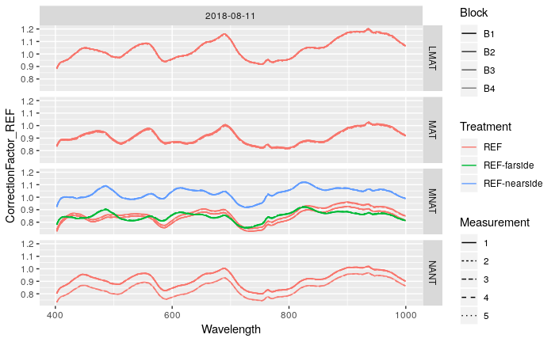

Look for correction factors very far from 1.0 or with odd peaks.

### 4.1.2 Plot Zoom Check References

Run the following code chunk interactively in RStudio to check references at specific sites/dates.

```r
# Useful Vectors for filtering
sites <- unlist(site_list)
dates <- df %>% select(Date) %>% unique() %>% slice(1:n()) %>% c() # list of dates present in data
## SPECIFY SITE/DATE/ETC to ZOOM IN ON
check_sites <- c("MNAT")
check_dates <- dates[[1]] # necessary to unlist dates vector
ref_check <- ref_data_all %>%
  filter(Date %in% check_dates) %>%
  filter(Site %in% check_sites)
## Plot Specified Correction Factors for quality check
cor_factor_plot_zoom <- ggplot(data = ref_check, mapping = aes(x = Wavelength, y = CorrectionFactor_REF)) +
  geom_line(aes(color=Treatment, linetype=Measurement, alpha=Block)) +
  facet_grid(Site ~ Date) +
  scale_alpha_discrete(range=c(1, 0.25))
```

```
Using alpha for a discrete variable is not advised.
```

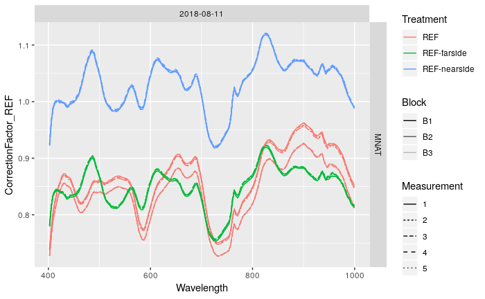

```r
cor_factor_plot_zoom
```

Look at associated dataframe to check info, specifically: *Weather*, *Notes*, or *int* (Integration Time) columns.

| filename | Site | FileNum | Date | int | Temp | Treatment | Weather | Notes | Measurement | Block |
| --- | --- | --- | --- | --- | --- | --- | --- | --- | --- | --- |
| UnispecData/Unispec6//2018-08-11/MNAT_00000.spu | MNAT | 0 | 2018-08-11 | 50 | 23.912 | REF |  |  | 1 | B2 |
| UnispecData/Unispec6//2018-08-11/MNAT_00001.spu | MNAT | 1 | 2018-08-11 | 50 | 24.156 | REF |  |  | 2 | B2 |
| UnispecData/Unispec6//2018-08-11/MNAT_00002.spu | MNAT | 2 | 2018-08-11 | 50 | 24.156 | REF |  |  | 3 | B2 |
| UnispecData/Unispec6//2018-08-11/MNAT_00003.spu | MNAT | 3 | 2018-08-11 | 50 | 24.400 | REF |  |  | 4 | B2 |
| UnispecData/Unispec6//2018-08-11/MNAT_00004.spu | MNAT | 4 | 2018-08-11 | 50 | 23.912 | REF |  |  | 5 | B2 |
| UnispecData/Unispec6//2018-08-11/MNAT_00005.spu | MNAT | 5 | 2018-08-11 | 50 | 24.156 | REF |  |  | 1 | B1 |
| UnispecData/Unispec6//2018-08-11/MNAT_00006.spu | MNAT | 6 | 2018-08-11 | 50 | 24.644 | REF |  |  | 2 | B1 |
| UnispecData/Unispec6//2018-08-11/MNAT_00007.spu | MNAT | 7 | 2018-08-11 | 50 | 24.644 | REF |  |  | 3 | B1 |
| UnispecData/Unispec6//2018-08-11/MNAT_00008.spu | MNAT | 8 | 2018-08-11 | 50 | 24.400 | REF |  |  | 4 | B1 |
| UnispecData/Unispec6//2018-08-11/MNAT_00009.spu | MNAT | 9 | 2018-08-11 | 50 | 24.644 | REF |  |  | 5 | B1 |
| UnispecData/Unispec6//2018-08-11/MNAT_00206.spu | MNAT | 206 | 2018-08-11 | 50 | 26.108 | REF-farside | Sunny, clear, a few large puffy clouds that did not cover the sun during measurements | Reference for side of greenhouse farther from Toolik Lake, taken facing back towards the lake. | 1 | B1 |
| UnispecData/Unispec6//2018-08-11/MNAT_00207.spu | MNAT | 207 | 2018-08-11 | 50 | 26.352 | REF-farside | Sunny, clear, a few large puffy clouds that did not cover the sun during measurements | Reference for side of greenhouse farther from Toolik Lake, taken facing back towards the lake. | 2 | B1 |
| UnispecData/Unispec6//2018-08-11/MNAT_00208.spu | MNAT | 208 | 2018-08-11 | 50 | 26.108 | REF-farside | Sunny, clear, a few large puffy clouds that did not cover the sun during measurements | Reference for side of greenhouse farther from Toolik Lake, taken facing back towards the lake. | 3 | B1 |
| UnispecData/Unispec6//2018-08-11/MNAT_00209.spu | MNAT | 209 | 2018-08-11 | 50 | 26.108 | REF-farside | Sunny, clear, a few large puffy clouds that did not cover the sun during measurements | Reference for side of greenhouse farther from Toolik Lake, taken facing back towards the lake. | 4 | B1 |
| UnispecData/Unispec6//2018-08-11/MNAT_00210.spu | MNAT | 210 | 2018-08-11 | 50 | 26.108 | REF-farside | Sunny, clear, a few large puffy clouds that did not cover the sun during measurements | Reference for side of greenhouse farther from Toolik Lake, taken facing back towards the lake. | 5 | B1 |
| UnispecData/Unispec6//2018-08-11/MNAT_00211.spu | MNAT | 211 | 2018-08-11 | 50 | 25.620 | REF-nearside |  | Reference for side of greenhouse closer to Toolik Lake, taken facing towards the Iktillik. | 1 | B1 |
| UnispecData/Unispec6//2018-08-11/MNAT_00212.spu | MNAT | 212 | 2018-08-11 | 50 | 25.864 | REF-nearside |  | Reference for side of greenhouse closer to Toolik Lake, taken facing towards the Iktillik. | 2 | B1 |
| UnispecData/Unispec6//2018-08-11/MNAT_00213.spu | MNAT | 213 | 2018-08-11 | 50 | 25.864 | REF-nearside |  | Reference for side of greenhouse closer to Toolik Lake, taken facing towards the Iktillik. | 3 | B1 |
| UnispecData/Unispec6//2018-08-11/MNAT_00214.spu | MNAT | 214 | 2018-08-11 | 50 | 25.620 | REF-nearside |  | Reference for side of greenhouse closer to Toolik Lake, taken facing towards the Iktillik. | 4 | B1 |
| UnispecData/Unispec6//2018-08-11/MNAT_00215.spu | MNAT | 215 | 2018-08-11 | 50 | 26.108 | REF-nearside |  | Reference for side of greenhouse closer to Toolik Lake, taken facing towards the Iktillik. | 5 | B1 |
| UnispecData/Unispec6//2018-08-11/MNAT_00000.spu | MNAT | 0 | 2018-08-11 | 50 | 23.912 | REF |  |  | 1 | B3 |
| UnispecData/Unispec6//2018-08-11/MNAT_00001.spu | MNAT | 1 | 2018-08-11 | 50 | 24.156 | REF |  |  | 2 | B3 |
| UnispecData/Unispec6//2018-08-11/MNAT_00002.spu | MNAT | 2 | 2018-08-11 | 50 | 24.156 | REF |  |  | 3 | B3 |
| UnispecData/Unispec6//2018-08-11/MNAT_00003.spu | MNAT | 3 | 2018-08-11 | 50 | 24.400 | REF |  |  | 4 | B3 |
| UnispecData/Unispec6//2018-08-11/MNAT_00004.spu | MNAT | 4 | 2018-08-11 | 50 | 23.912 | REF |  |  | 5 | B3 |
| UnispecData/Unispec6//2018-08-11/MNAT_00206.spu | MNAT | 206 | 2018-08-11 | 50 | 26.108 | REF-farside | Sunny, clear, a few large puffy clouds that did not cover the sun during measurements | Reference for side of greenhouse farther from Toolik Lake, taken facing back towards the lake. | 1 | B2 |
| UnispecData/Unispec6//2018-08-11/MNAT_00207.spu | MNAT | 207 | 2018-08-11 | 50 | 26.352 | REF-farside | Sunny, clear, a few large puffy clouds that did not cover the sun during measurements | Reference for side of greenhouse farther from Toolik Lake, taken facing back towards the lake. | 2 | B2 |
| UnispecData/Unispec6//2018-08-11/MNAT_00208.spu | MNAT | 208 | 2018-08-11 | 50 | 26.108 | REF-farside | Sunny, clear, a few large puffy clouds that did not cover the sun during measurements | Reference for side of greenhouse farther from Toolik Lake, taken facing back towards the lake. | 3 | B2 |
| UnispecData/Unispec6//2018-08-11/MNAT_00209.spu | MNAT | 209 | 2018-08-11 | 50 | 26.108 | REF-farside | Sunny, clear, a few large puffy clouds that did not cover the sun during measurements | Reference for side of greenhouse farther from Toolik Lake, taken facing back towards the lake. | 4 | B2 |
| UnispecData/Unispec6//2018-08-11/MNAT_00210.spu | MNAT | 210 | 2018-08-11 | 50 | 26.108 | REF-farside | Sunny, clear, a few large puffy clouds that did not cover the sun during measurements | Reference for side of greenhouse farther from Toolik Lake, taken facing back towards the lake. | 5 | B2 |
| UnispecData/Unispec6//2018-08-11/MNAT_00211.spu | MNAT | 211 | 2018-08-11 | 50 | 25.620 | REF-nearside |  | Reference for side of greenhouse closer to Toolik Lake, taken facing towards the Iktillik. | 1 | B2 |
| UnispecData/Unispec6//2018-08-11/MNAT_00212.spu | MNAT | 212 | 2018-08-11 | 50 | 25.864 | REF-nearside |  | Reference for side of greenhouse closer to Toolik Lake, taken facing towards the Iktillik. | 2 | B2 |
| UnispecData/Unispec6//2018-08-11/MNAT_00213.spu | MNAT | 213 | 2018-08-11 | 50 | 25.864 | REF-nearside |  | Reference for side of greenhouse closer to Toolik Lake, taken facing towards the Iktillik. | 3 | B2 |
| UnispecData/Unispec6//2018-08-11/MNAT_00214.spu | MNAT | 214 | 2018-08-11 | 50 | 25.620 | REF-nearside |  | Reference for side of greenhouse closer to Toolik Lake, taken facing towards the Iktillik. | 4 | B2 |
| UnispecData/Unispec6//2018-08-11/MNAT_00215.spu | MNAT | 215 | 2018-08-11 | 50 | 26.108 | REF-nearside |  | Reference for side of greenhouse closer to Toolik Lake, taken facing towards the Iktillik. | 5 | B2 |

## 4.2 Choose White References:

Based on the above quality check, choose reference files by entering the appropriate file numbers in **UnispecData/Unispec6//2018_unispec_key.csv** for the rows where the column *Treatment* = **REF**. There are typically 5 reference measurements per *Date* / *Site*.

Then rerun the **Load Keys** and **Join Data & keys** sections above to update the `df` dataframe. The following plots your chosen references.

```
Expected 4 pieces. Missing pieces filled with `NA` in 3600 rows [1801, 1802, 1803, 1804, 1805, 1806, 1807, 1808, 1809, 1810, 1811, 1812, 1813, 1814, 1815, 1816, 1817, 1818, 1819, 1820, ...].
```

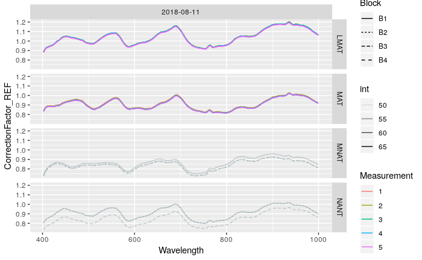

| Date | Site | Block | Weather | Notes | FileNums |
| --- | --- | --- | --- | --- | --- |
| 2018-08-11 | LMAT | B1, B2, B3, B4 | Sunny, still, streaks of high thin clouds |  | 0,1,2,3,4 |
| 2018-08-11 | MAT | B1, B2, B3, B4 | Sunny, still, high thin streaks of clouds | Some droplets on vegetation from rain the previous night, but you only get so many sunny days! Waited 'til ~ 11:00am for stuff to dry. | 1,2,3,4,5 |
| 2018-08-11 | MNAT | B1 |  |  | 5,6,7,8,9 |
| 2018-08-11 | MNAT | B2, B3 |  |  | 0,1,2,3,4 |
| 2018-08-11 | NANT | B1, B2 | sunny with high thin clouds |  | 6,7,8,9,10 |
| 2018-08-11 | NANT | B3 | sunny with high thin clouds |  | 1,2,3,4,5 |

## 4.3 Apply References

Apply your chosen references to actual spectral data to create the tidy dataframe `df_tidy` containing corrected sepectral reflectance values.

## 4.4 Save Spectral Data

# 5 Investigate Spectral Data

## 5.1 Plot Spectra: Site vs. Block

For the following code, make sure you select only one date per site. The 5 measurements per plot are averaged as a line and one standard deviation above and below shaded. Interactively edit the “PLOT SELECTION” vectors in the code chunk below to investigate specific data.

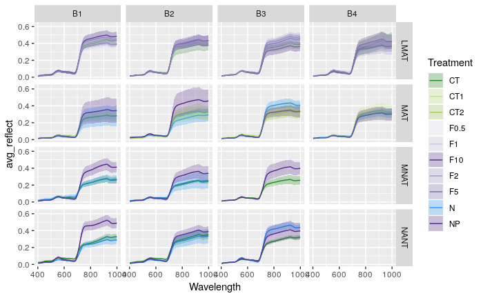

## 5.2 Plot Spectra: Site vs. Date

Average plot averages by block. NOTE: Ask Laura what the correct error propogation is here.

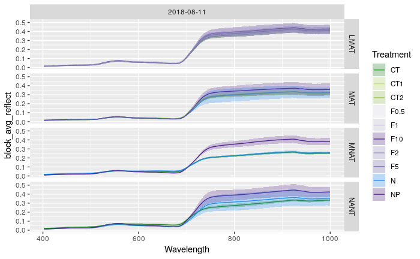

# 6 Calculate Vegetation Indices

Currently, this only works for NDVI, EVI, and EVI2 as I haven’t worked out spectral interpolation yet and the other indices need reflectance at a specific value (not a range).

## 6.1 Plot NDVI: Site vs. Block

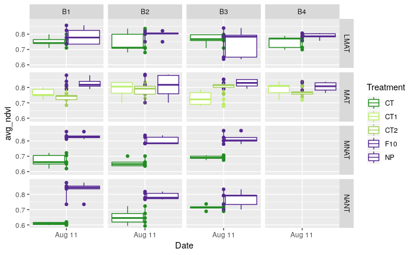

## 6.2 Save Vegetation Index Data

Append data to yearly r dataframe or .csv file. Write code to read in saved data and remove duplicate rows. >> ASK JIM: I’m not sure what the best data organization system is yet.